# Data Lab 10: Network Visualizations

Anin Nair

``13-11-2023

### 1. Setting up the libraries and datsets

```r
library (tidyverse)
```

```r
library(ggplot2)
library(ggrepel)
library(ggnetwork)
library(network)
nodes <- read.csv("artists_2012_2020.csv")
edges <- read.csv("collaboration_edgelist_2012_2020.csv")
head(edges)
```

|  | Artist_1 | Artist_2 |
| --- | --- | --- |
| 1 | 2 Chainz | A$AP Rocky |
| 2 | 2 Chainz | B.o.B. |
| 3 | 2 Chainz | Big Sean |
| 4 | 2 Chainz | Chance the Rapper |
| 5 | 2 Chainz | Drake |
| 6 | 2 Chainz | Gucci Mane |

```r
head(nodes)
```

|  | Artist | Gender | GrammyWinner | GrammyNomminee | YearStarted |
| --- | --- | --- | --- | --- | --- |
| 1 | 2 Chainz | 0 | 1 | 0 | 1997 |
| 2 | 21 Savage | 0 | 1 | 0 | 2012 |
| 3 | 42 Dugg | 0 | 0 | 0 | 2017 |
| 4 | 50 Cent | 0 | 1 | 0 | 1996 |
| 5 | 6ix9ine | 0 | 0 | 0 | 2012 |
| 6 | 6LACK | 0 | 0 | 1 | 2011 |

### 2.Setting up the nodes and the edges

```r
knitr::kable(nodes)
```

[output not shown]

[output cut: 253 more lines]

```r
knitr::kable(edges)
```

| Artist_1 | Artist_2 |
| --- | --- |
| 2 Chainz | A$AP Rocky |
| 2 Chainz | B.o.B. |
| 2 Chainz | Big Sean |
| 2 Chainz | Chance the Rapper |
| 2 Chainz | Drake |
| 2 Chainz | Gucci Mane |
| 2 Chainz | Jason Derulo |
| 2 Chainz | Jeezy |
| 2 Chainz | Jhene Aiko |
| 2 Chainz | Juicy J |
| 2 Chainz | Kanye West |
| 2 Chainz | Kcamp |
| 2 Chainz | Kendrick Lamar |
| 2 Chainz | Lil Wayne |
| 2 Chainz | Nicki Minaj |
| 2 Chainz | Pharrell Williams |
| 2 Chainz | Pusha T |
| 2 Chainz | Quavo |
| 2 Chainz | TeeFLii |
| 2 Chainz | Travis Scott |
| 2 Chainz | Trey Songz |
| 2 Chainz | Ty Dolla $ign |
| 2 Chainz | Wiz Khalifa |
| 2 Chainz | YG |
| 21 Savage | Cardi B |
| 21 Savage | DJ Khaled |
| 21 Savage | Drake |
| 21 Savage | Future |
| 21 Savage | Metro Boomin |
| 21 Savage | Post Malone |

[output cut: 515 more lines]

```r
network_data <- network(x=edges, vertices=nodes,directed=FALSE)
network_data
```

```
##  Network attributes:
##   vertices = 284
##   directed = FALSE
##   hyper = FALSE
##   loops = FALSE
##   multiple = FALSE
##   bipartite = FALSE
##   total edges= 605
##     missing edges= 0
##     non-missing edges= 605
##
##  Vertex attribute names:
##     Gender GrammyNomminee GrammyWinner vertex.names YearStarted
##
## No edge attributes
```

### 3. Network Plot - 1

Here I’ve plotted a network visualization of artists and Grammy nominees. This first plot specifies the gender of the artists. There is no specific reason as to why I chose the color, I just felt blue and violetred where suited well for a binary variable and also color-blind friendly. I believe that none of the layouts did good enough for this particular dataset but I chose this one because the *fruchtermanreingold* is the most visually appealing.

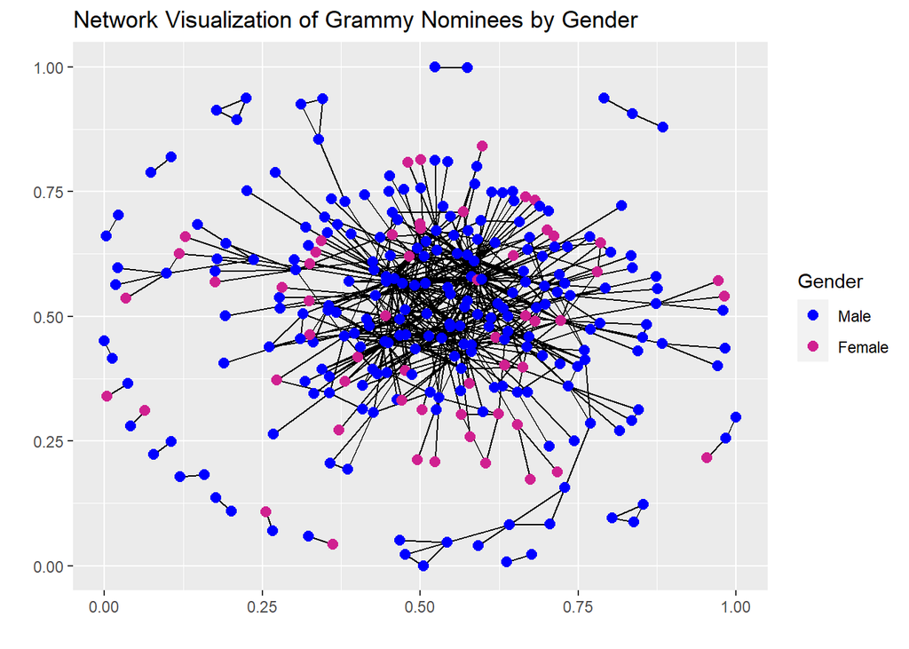

```r
net <- ggnetwork(network_data,
layout="fruchtermanreingold")
ggplot(net, aes(x=x,y=y,xend=xend,yend=yend)) + geom_edges() +geom_nodes(aes(color = as.factor(Gender)), size = 2.5) + labs(x = " ", y = " " , color = "Gender")+   ggtitle("Network Visualization of Grammy Nominees by Gender ") + scale_color_manual(labels = c("Male", "Female"), values = c("blue", "violetred"))
```

```r
#+ geom_nodelabel_repel(aes(label = nodes$Artist)) + theme_blank()
```

## 4. Network Plot - 2

Here I’ve plotted a network visualization of artists and Grammy nominees. This first plot specifies if they won a Grammy or not. There is no specific reason as to why I chose the color, I just felt felt blue and violetred suited well for a binary variable and also color-blind friendly. I believe that none of the layouts did good enough for this particular dataset but I chose this one because the *fruchtermanreingold* is the most visually appealing.

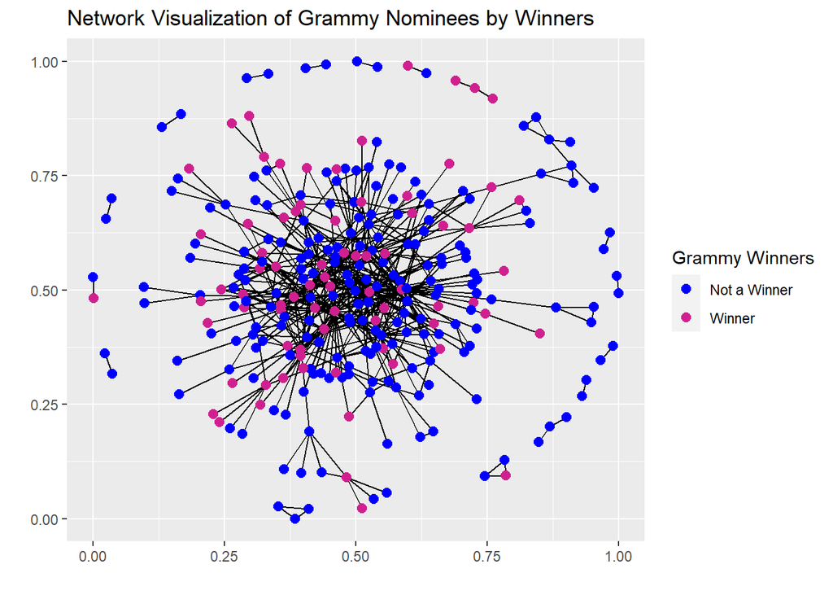

```r
net <- ggnetwork(network_data,
layout="fruchtermanreingold")
ggplot(net, aes(x=x,y=y,xend=xend,yend=yend)) + geom_edges() +geom_nodes(aes(color = as.factor(GrammyWinner)), size = 2.5) + labs(x = " ", y = " " , color = "Grammy Winners")+ ggtitle("Network Visualization of Grammy Nominees by Winners ")+ scale_color_manual(labels = c("Not a Winner", "Winner"), values = c("blue", "violetred"))
```

## Note

I was unfortunately unable to add labels to both of the plots. I tried all possible ways but I kept getting an error “Artist not found” even though I have a variable named Artist. I can email to you the image, because I’m not sure how to attach it on an R notebook file!